# Lab1 - baseball stats

Moneyball focuses on the “quest for the secret of success in baseball”. It follows a low-budget team, the Oakland A’s, who believed that underused statistics, such as a player’s ability to get on base, better predict the ability to score runs, rather than typical statistics like HR’s, RBI’s, and BA. Obtaining players who excelled in these underused statistics turned out to be much more affordable for the team.

We’ll be looking at data from all 30 MLB teams and examining the relationships between in-game statistics.

```r
# access the OpenIntro website and fetch the `mlb11` data set.
download.file("http://www.openintro.org/stat/data/mlb11.RData", destfile = "mlb11.RData")
load("mlb11.RData")
```

Let’s load up the data for the 2011 season. In addition to `RS`, there are 7 traditionally-used variables in the data set: `{AB, H, HR, BA, SO, SB, W}`. There are also 3 newer variables: `OBP`, slugging % `SLG`, + on-base plus slugging `OBPS`. For the 1st portion of the analysis, we’ll consider the 7 traditional variables. At the end of the lab, we’ll work w/ the newer variables.

`mlb11` = a **data frame** w/ 30 observations of 12 variables.

## The Data: 2011 baseball statistics

Each row = different team w/ an index (not actually part of dataset), team name, + remaining cols = team-specific metrics

```r
# get observations/rows and variables/cols
dim(mlb11)
```

```
## [1] 30 12
```

```r
# get col names
names(mlb11)
```

```
##  [1] "team"         "runs"         "at_bats"      "hits"
##  [5] "homeruns"     "bat_avg"      "strikeouts"   "stolen_bases"
##  [9] "wins"         "new_onbase"   "new_slug"     "new_obs"
```

## Some Exploration

```r
# returns col as a vector
mlb11$runs
```

```r
head(mlb11)
```

```
##                  team runs at_bats hits homeruns bat_avg strikeouts
## 1       Texas Rangers  855    5659 1599      210   0.283        930
## 2      Boston Red Sox  875    5710 1600      203   0.280       1108
## 3      Detroit Tigers  787    5563 1540      169   0.277       1143
## 4  Kansas City Royals  730    5672 1560      129   0.275       1006
## 5 St. Louis Cardinals  762    5532 1513      162   0.273        978
## 6       New York Mets  718    5600 1477      108   0.264       1085
##   stolen_bases wins new_onbase new_slug new_obs
## 1          143   96      0.340    0.460   0.800
## 2          102   90      0.349    0.461   0.810
## 3           49   95      0.340    0.434   0.773
## 4          153   71      0.329    0.415   0.744
## 5           57   90      0.341    0.425   0.766
## 6          130   77      0.335    0.391   0.725
```

```r
tail(mlb11)
```

```
##                    team runs at_bats hits homeruns bat_avg strikeouts
## 25       Tampa Bay Rays  707    5436 1324      172   0.244       1193
## 26       Atlanta Braves  641    5528 1345      173   0.243       1260
## 27 Washington Nationals  624    5441 1319      154   0.242       1323
## 28 San Francisco Giants  570    5486 1327      121   0.242       1122
## 29     San Diego Padres  593    5417 1284       91   0.237       1320
## 30     Seattle Mariners  556    5421 1263      109   0.233       1280
##    stolen_bases wins new_onbase new_slug new_obs
## 25          155   91      0.322    0.402   0.724
## 26           77   89      0.308    0.387   0.695
## 27          106   80      0.309    0.383   0.691
## 28           85   86      0.303    0.368   0.671
## 29          170   71      0.305    0.349   0.653
## 30          125   67      0.292    0.348   0.640
```

### mosaic

`mosaic` package streamlines all commands needed in course = **specifically designed by a team of NSF-funded educators to make R more accessible to statistics students** = doesn’t provide new functionality, so much as make existing functionality more logical, consistent, all the while emphasizing importants concepts in statistics.

```r
#install.packages("mosaic")
library(mosaic)
library(lattice)
library(tidyverse)
```

Centerpiece of the `mosaic` syntax = the use of the *modeling language*, which involves the use of a tilde (~), which can be read as *“is a function of”*. For example, to create a simple plot of runs each team scored vs. hits:

```r
# simple plot of runs each team scored vs. H
xyplot(runs ~ hits, mlb11)
```

By default = scatterplot w/ each $(x,y)$ pair indicated by an open circle.

**2. Is there an association between runs scored and hits? How would you describe it?**

- *Yes, moderate-to-strongly positive*

Now plot only total # of runs.

```r
histogram( ~ runs, mlb11)
bwplot( ~ runs, mlb11)
```

**3. Describe the distribution of runs scored among MLB teams in 2011. What is the median?**

```r
median(mlb11$runs)
```

```
## [1] 705.5
```

```r
mean(mlb11$runs)
```

```
## [1] 693.6
```

### Additional R functionalities

Get the total # of HR and SO by the Texas Rangers (1st row in data), + to do so every row = add the vectors together + R computes all sums simultaneously.

```r
# all teams
mlb11$homeruns + mlb11$strikeouts
# just rangers
mlb11[1,"homeruns"] + mlb11[1,"strikeouts"]
# tidyverse way
library(tidyverse)
mlb11 %>%
  filter(team == "Texas Rangers") %>%
  mutate(sumHR_SO = homeruns+strikeouts) %>%
  select(sumHR_SO)
```

**4. Which team had the highest cumulative number of strikeouts and homeruns in 2011?**

```r
library(tidyverse)
mlb11[which.max(mlb11$homeruns + mlb11$strikeouts),"team"]
```

```
## [1] Washington Nationals
## 30 Levels: Arizona Diamondbacks Atlanta Braves ... Washington Nationals
```

```r
# tidyway
mlb11 %>%
  mutate(sumHR_SO = homeruns+strikeouts) %>%
  select(team,sumHR_SO) %>%
  arrange(desc(sumHR_SO)) %>%
  head()
```

```
##                   team sumHR_SO
## 1 Washington Nationals     1477
## 2      Cincinnati Reds     1433
## 3       Atlanta Braves     1433
## 4    Cleveland Indians     1423
## 5 Arizona Diamondbacks     1421
## 6   Pittsburgh Pirates     1415
```

**Which home run observations were greater than 200?**

```r
mlb11$homeruns > 200
```

5. Which MLB teams had more than 200 home runs in 2011?

```r
subset(mlb11, homeruns > 200)
```

```
##               team runs at_bats hits homeruns bat_avg strikeouts
## 1    Texas Rangers  855    5659 1599      210   0.283        930
## 2   Boston Red Sox  875    5710 1600      203   0.280       1108
## 7 New York Yankees  867    5518 1452      222   0.263       1138
##   stolen_bases wins new_onbase new_slug new_obs
## 1          143   96      0.340    0.460   0.800
## 2          102   90      0.349    0.461   0.810
## 7          147   97      0.343    0.444   0.788
```

```r
# tidyway
mlb11 %>%
  filter(homeruns>200) %>%
  select(team)
```

```
##               team
## 1    Texas Rangers
## 2   Boston Red Sox
## 3 New York Yankees
```

## Summaries and tables

*Good 1st step in any analysis = distill all the info from the data into a few summary statistics + graphics*

```r
summary(mlb11$runs)
```

```r
734 - 629
```

Built-in functions to compute summary stats one-by-one, like mean, median, and variance of `runs`, type

```r
mean(~runs, data=mlb11)
var(~runs, data=mlb11)
median(~runs, data=mlb11)
```

Command `mosaic::favstats()`, allows us to compute all of this info (+ more) at once, in a data frame.

```r
mosaic::favstats(~runs, data=mlb11)
```

While it makes sense to describe a quantitative variable like `runs` in terms of these statistics, what about *categorical* data? Instead consider the **sample frequency** or **relative frequency distribution**. `tally()` does this by counting the # of times each kind of response was given.

```r
# see # of teams who hit at least 200 homeruns
mlb11$HighHR <- mlb11$homeruns >= 200
mlb11$HighHR

# counts of records with HighHR
mosaic::tally(~ HighHR, data=mlb11)
```

or instead look at the **relative frequency distribution** by including a new arg

```r
mosaic::tally(~ HighHR, data=mlb11, format="proportion")
```

In each of the above steps, we make use of a new variable, `HighHR` + use it in as the input for `tally()`.

Next, we make a bar chart of entries in the table by putting the table inside `barchart()`.

```r
barchart(tally(~HighHR, data=mlb11, margins=FALSE), horizontal=FALSE)
```

We’ve computed the table then immediately applied the graphical function, `barchart`.

6. Create a numerical summary for `stolen_bases` and `wins`, and compute the interquartile range for each.

```r
mosaic::favstats(mlb11$stolen_bases)
```

```
##  min    Q1 median     Q3 max  mean       sd  n missing
##   49 89.75    107 130.75 170 109.3 29.86885 30       0
```

```r
mosaic::favstats(mlb11$stolen_bases)$max - mosaic::favstats(mlb11$stolen_bases)$min
```

```
## [1] 121
```

```r
mosaic::favstats(mlb11$wins)
```

```
##  min Q1 median Q3 max     mean       sd  n missing
##   56 72     80 90 102 80.96667 11.41531 30       0
```

```r
mosaic::favstats(mlb11$wins)$max - mosaic::favstats(mlb11$wins)$min
```

```
## [1] 46
```

7. Compute the relative frequency distribution for teams with at least 90 `wins`. How many teams reached 90 wins?

```r
mlb11$HighW <- mlb11$wins >= 90
length(mlb11$HighW)
```

```
## [1] 30
```

```r
mosaic::tally(~ HighW, data=mlb11, format="proportion")
```

```
## HighW
##  TRUE FALSE
##   0.3   0.7
```

`tally` can be used to tabulate any # of variables you provide.

8. What is shown in the following table? How many teams won >= 90 games + hit >= 200 HR?

```r
mlb11$HighWins <- mlb11$wins >=90
mosaic::tally(HighWins ~ HighHR, data=mlb11, format="count")
```

9. Describe the center, shape, + spread of `stolen_bases`, using an appropriate plot + the appropriate metrics.

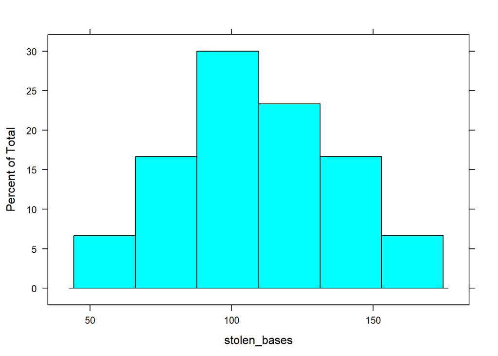

```r
lattice::histogram( ~ stolen_bases, mlb11)
```

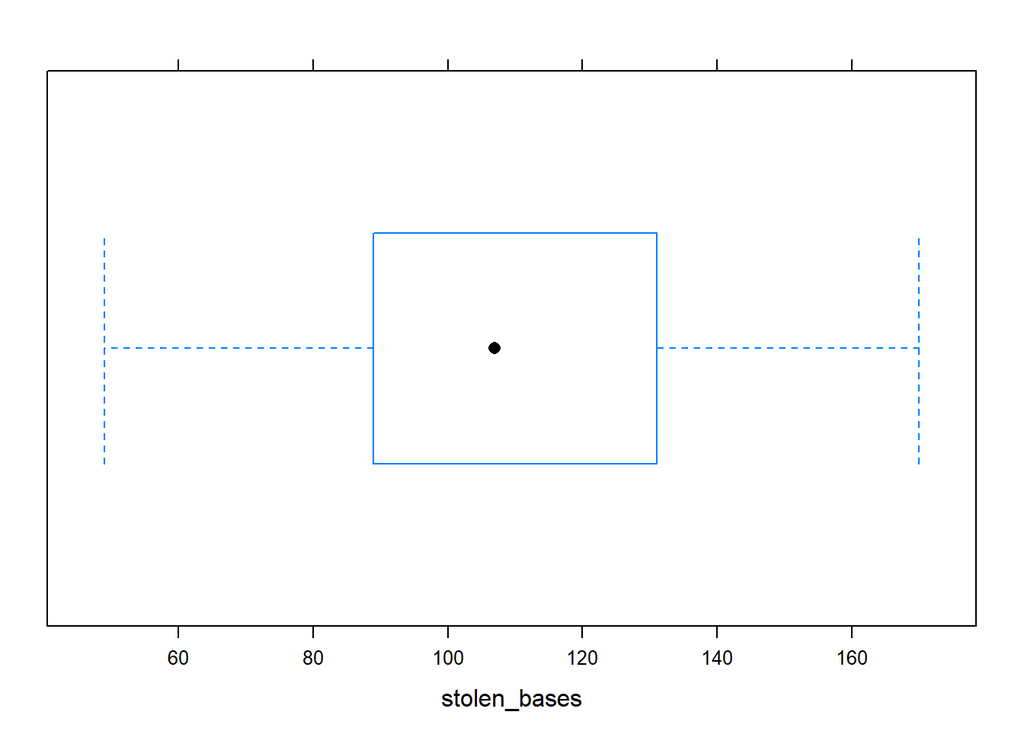

```r
lattice::bwplot( ~ stolen_bases, mlb11)
```

```r
mosaic::favstats(mlb11$stolen_bases)
```

```
##  min    Q1 median     Q3 max  mean       sd  n missing
##   49 89.75    107 130.75 170 109.3 29.86885 30       0
```

This is pretty normal, with a median and mean just below 110 SB’s, with a spread of about +/- 30 SB’s.

**10. A coach is interested in the link between `stolen_bases` and `runs`. Show the coach a scatter plot, and describe the association. As you make the plot, think carefully about which of these two variables is the explanatory variable (and which is the response).**

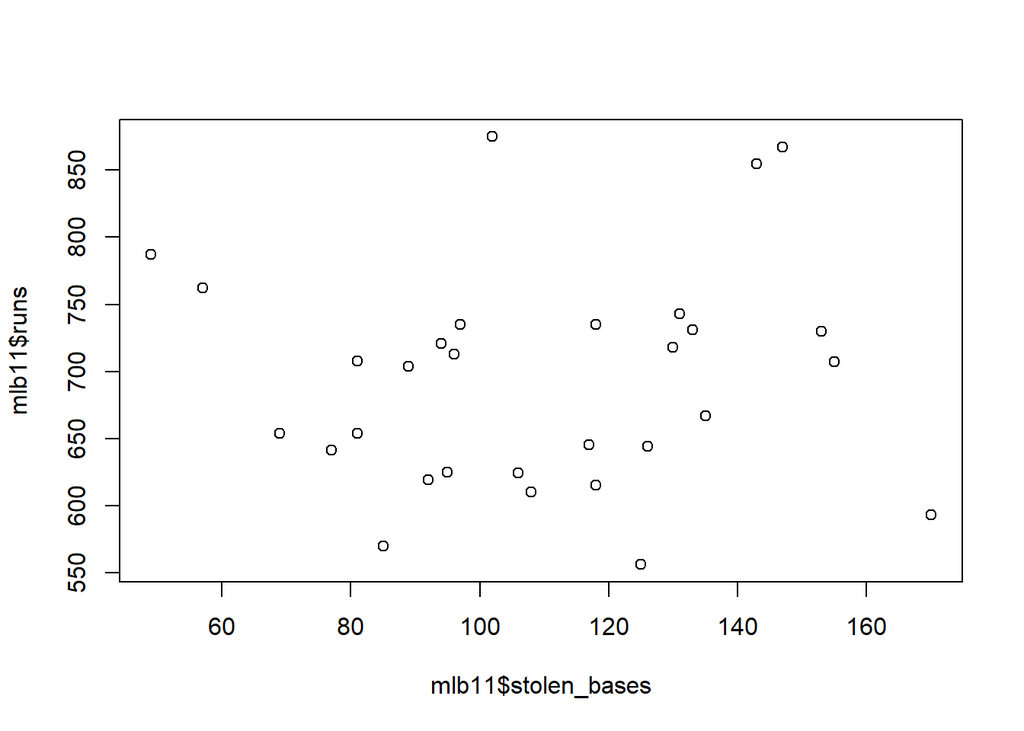

```r
### Enter code here.
plot(mlb11$stolen_bases,mlb11$runs)
```

```r
cor(mlb11$stolen_bases,mlb11$runs)
```

```
## [1] 0.05398141
```

There seems to be no association between stolen bases and runs, as we can see from the scatterplot and the low Pearsons’ correlation coefficient.

**11. How can you change the x and y labels on your plots? How can you add a title?

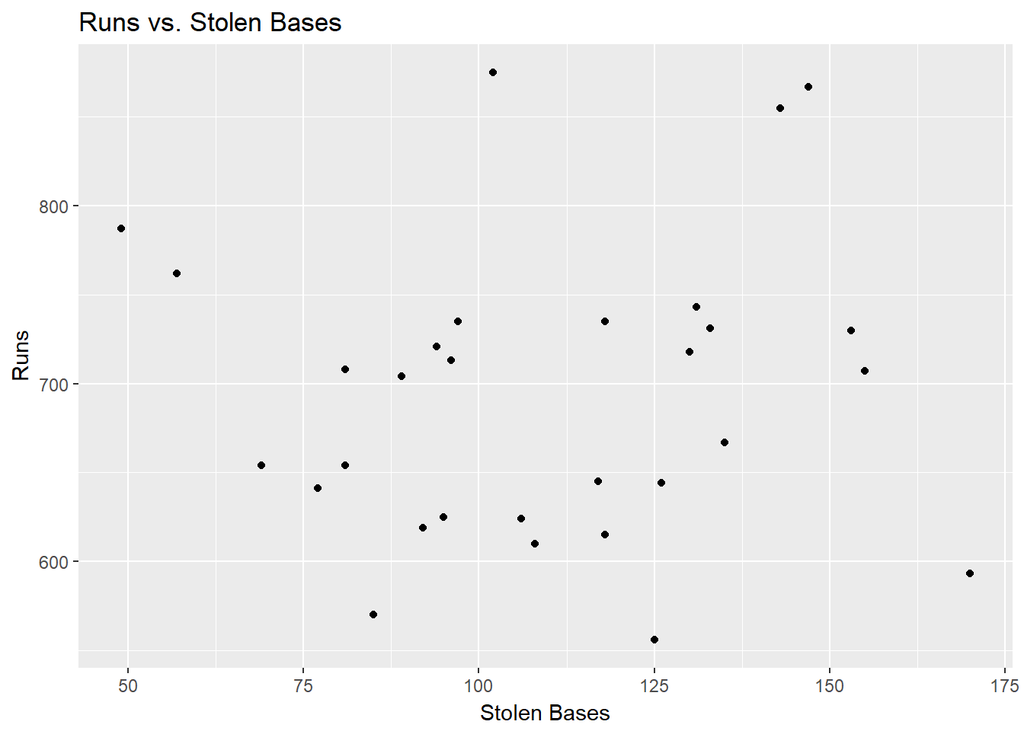

```r
### Enter code here.
library(ggplot2)
ggplot(mlb11, aes(stolen_bases,runs)) +
  geom_point() +
  xlab("Stolen Bases") +
  ylab("Runs") +
  ggtitle("Runs vs. Stolen Bases")
```

```r
cor(mlb11$stolen_bases,mlb11$runs)
```

```
## [1] 0.05398141
```

12. Using visual evidence, find the variable that you think seems to boast the strongest association to `runs`. Consider any continuous variables between columns 3 (`at_bats`) and 12 (`new_obs`).

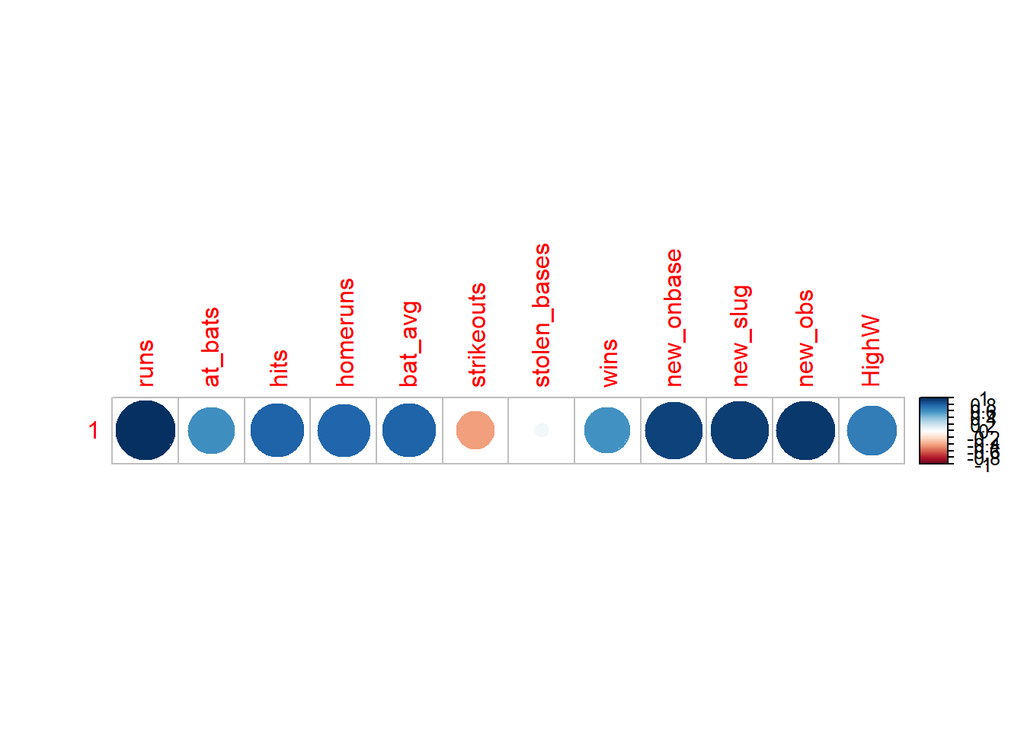

```r
#names(mlb11)
corr_mat <- cor(mlb11$runs,mlb11[,-1])
corrplot::corrplot(corr_mat)
```

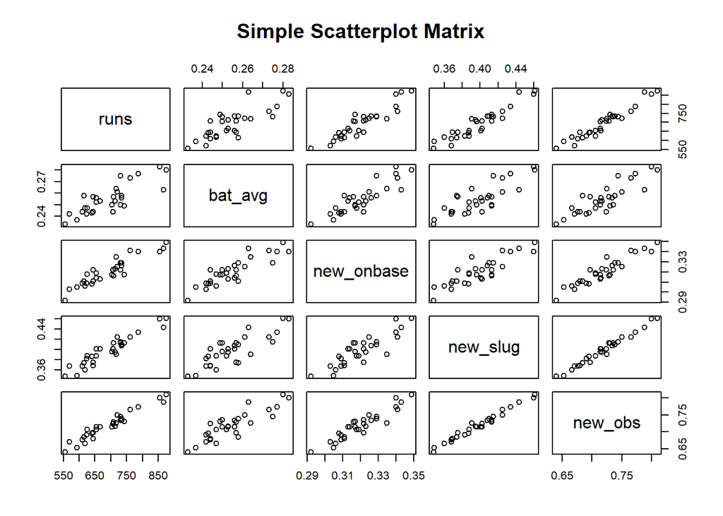

```r
pairs(~runs+bat_avg+new_onbase+new_slug+new_obs
      ,data=mlb11
      ,main="Simple Scatterplot Matrix")
```

```r
cor(mlb11[-1])
```

```
##                     runs     at_bats       hits   homeruns    bat_avg
## runs          1.00000000  0.61062705  0.8012108  0.7915577  0.8099859
## at_bats       0.61062705  1.00000000  0.8464720  0.3765152  0.7553744
## hits          0.80121081  0.84647201  1.0000000  0.4708379  0.9879576
## homeruns      0.79155769  0.37651521  0.4708379  1.0000000  0.4715115
## bat_avg       0.80998589  0.75537437  0.9879576  0.4715115  1.0000000
## strikeouts   -0.41153120 -0.46342423 -0.6172284 -0.1707547 -0.6348140
## stolen_bases  0.05398141 -0.10752931 -0.1263302 -0.1173235 -0.1231475
## wins          0.60080877  0.06215611  0.2976591  0.6606140  0.3507933
## new_onbase    0.92146907  0.59814536  0.8548459  0.6163270  0.8823015
## new_slug      0.94703240  0.62027677  0.8182380  0.8628315  0.8284896
## new_obs       0.96691630  0.62790901  0.8508329  0.8106669  0.8670994
## HighW         0.69570428  0.14218008  0.4552882  0.5870790  0.5201558
##              strikeouts stolen_bases        wins  new_onbase    new_slug
## runs         -0.4115312   0.05398141  0.60080877  0.92146907  0.94703240
## at_bats      -0.4634242  -0.10752931  0.06215611  0.59814536  0.62027677
## hits         -0.6172284  -0.12633021  0.29765911  0.85484588  0.81823795
## homeruns     -0.1707547  -0.11732353  0.66061399  0.61632698  0.86283152
## bat_avg      -0.6348140  -0.12314745  0.35079332  0.88230150  0.82848956
## strikeouts    1.0000000   0.08764160 -0.28072689 -0.48688025 -0.40982184
## stolen_bases  0.0876416   1.00000000 -0.06459410 -0.03325633 -0.07412811
## wins         -0.2807269  -0.06459410  1.00000000  0.55227777  0.61416591
## new_onbase   -0.4868803  -0.03325633  0.55227777  1.00000000  0.87186451
## new_slug     -0.4098218  -0.07412811  0.61416591  0.87186451  1.00000000
## new_obs      -0.4439747  -0.06184629  0.61207502  0.93728337  0.98776446
## HighW        -0.3426284  -0.01907229  0.79262844  0.66489508  0.68443344
##                  new_obs       HighW
## runs          0.96691630  0.69570428
## at_bats       0.62790901  0.14218008
## hits          0.85083295  0.45528816
## homeruns      0.81066685  0.58707903
## bat_avg       0.86709944  0.52015578
## strikeouts   -0.44397466 -0.34262836
## stolen_bases -0.06184629 -0.01907229
## wins          0.61207502  0.79262844
## new_onbase    0.93728337  0.66489508
## new_slug      0.98776446  0.68443344
## new_obs       1.00000000  0.69815537
## HighW         0.69815537  1.00000000
```

`new_obs` seems to boast the strongest association to `runs`.

13. What is the variance in the number of strikeouts for each team during the 2011 season?

```r
var(mlb11$strikeouts)
```

```
## [1] 11674.8
```

14. Make a new variable, `high_BA`, to represent teams that hit for a batting average of 0.270 or more. How many teams fit into this group?

```r
mlb11$high_BA <- mlb11$bat_avg >= .270
sum(mlb11$high_BA)
```

```
## [1] 5
```

15. You can use `mosaic::favstats` to get the summary statistics within each `high_BA` group, and `bwplot()` to make boxplots. For example, what appears to be the link between `homeruns` and `high_BA`? Do teams with higher batting averages tend to hit more home runs?

```r
mosaic::favstats(homeruns ~ high_BA, data = mlb11)
```

```
##   high_BA min  Q1 median  Q3 max   mean       sd  n missing
## 1   FALSE  91 114    154 172 222 147.16 34.91738 25       0
## 2    TRUE 129 162    169 203 210 174.60 32.89833  5       0
```

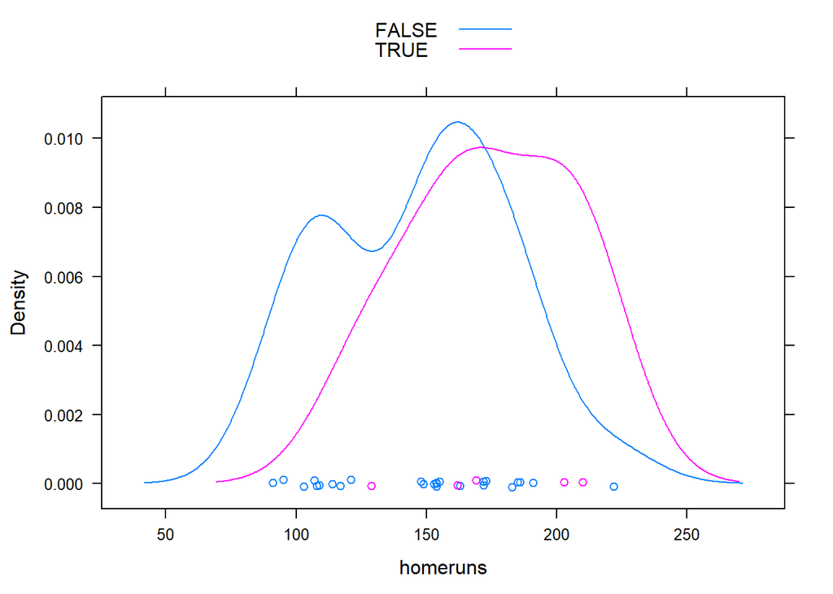

```r
lattice::densityplot(~ homeruns, groups = high_BA, data = mlb11, auto.key = TRUE)
```

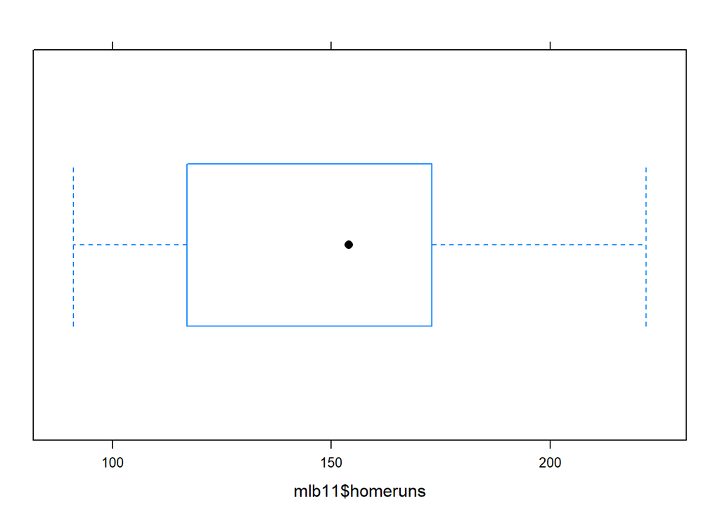

```r
lattice::bwplot(mlb11$homeruns, groups = mlb11$high_BA, data = mlb11)
```

16. Repeat the code above, only using `stolen_bases` instead of `homeruns`. Does there appear to be a link between `stolen bases` and `high_BA`?

```r
mosaic::favstats(stolen_bases ~ high_BA, data = mlb11)
```

```
##   high_BA min Q1 median  Q3 max  mean       sd  n missing
## 1   FALSE  69 92    108 130 170 111.0 26.08480 25       0
## 2    TRUE  49 57    102 143 153 100.8 47.72002  5       0
```

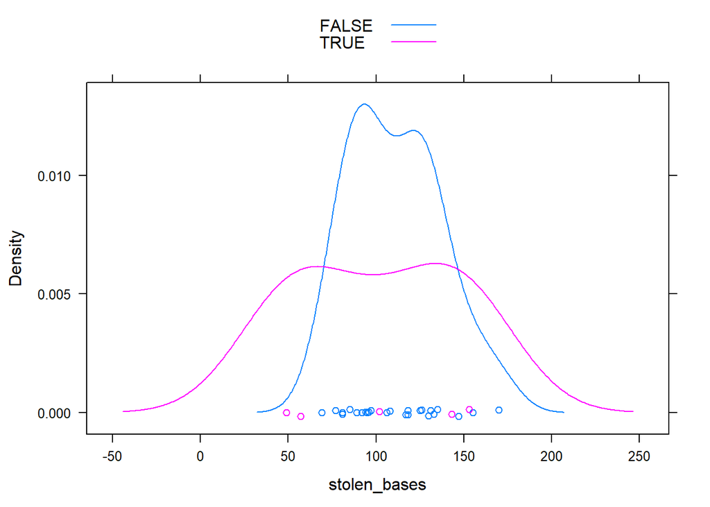

```r
lattice::densityplot(~ stolen_bases, groups = high_BA, data = mlb11, auto.key = TRUE)
```

Portions of this lab were adapted for OpenIntro by Andrew Bray and Mine Çetinkaya-Rundel from a lab written by Mark Hansen of UCLA Statistics, a product of OpenIntro that is released under a [Creative Commons License](http://creativecommons.org/licenses/by-sa/3.0)